UNIVERSIDADE ESTADUAL DA PARAÍBA - UEPB

CENTRO DE CIÊNCIAS E TECNOLOGIA - CCT

DEPARTAMENTO DE ESTATÍSTICA

ANÁLISE DE SÉRIES TEMPORAIS

DOCENTE: DR. PEDRO MONTEIRO DE ALMEIDA JUNIOR

DISCENTES: HILLNARA DE P. A. F. CARVALHO e JOÃO VITOR A. A. DE SOUZA

# 1 Introdução

Séries Temporais avalia o comportamento de uma variável ao longo do tempo. As observções coletadas são usada para analisar e entender o passado e para prever o futuro.

No processo de séries temporais existem três tipos de componentes:

- **Tendência:** Ocorre quando a variável da série temporal apresenta um crescimento ou decrescimento em um certo perériodo de tempo;
- **Sazonalidade:** Corresponde a um padão fixo que se repete no mesmo período de tempo específico;
- **Erro aleatório:** Mostra todos os efeitos que não foram incluso pela série (movimentos irregulares explicados por causas desconhecidas).

# 2 Descrição dos dados

O dataset contém dados históricos de sacos de cimentos vendidos no estado da Paraíba, do dia 01 de janeiro de 2017 ao dia 01 de fevereiro de 2021. http://ipeadata.gov.br/Default.aspx

# 3 Objetivo

O intuito desta análise é avaliar e tentar prever os dados da série, os dados são registrados mensalmente. As análises foram realizadas no `software R.`

# 4 Metodologia

Para o desenvolvimento deste trabalho, a metodologia adotada teve como base a pesquisa realizada na plataforma de dados *ipeadata* site

## 4.1 Bibliotécas

```r
library(TSA)
library(forecast)
library(fpp3)
library(knitr)
```

## 4.2 Banco de dados

```r
library(readxl)

Series <- read_excel("C:/Users/hilln/OneDrive/Área de Trabalho/Series.xls")
cimento<-Series
kable(head(cimento))
```

| Data | Consumo |
| --- | --- |
| 2017-01-01 | 70672 |
| 2017-02-01 | 58962 |
| 2017-03-01 | 73459 |
| 2017-04-01 | 59150 |
| 2017-05-01 | 64833 |
| 2017-06-01 | 63840 |

## 4.3 Transformando para formato tstible

```r
serie <- cimento %>%
  mutate(Data = yearmonth(Data)) %>%
  as_tsibble(index = Data)
serie
```

```
## # A tsibble: 50 x 2 [1M]
##        Data Consumo
##       <mth>   <dbl>
##  1 2017 jan   70672
##  2 2017 fev   58962
##  3 2017 mar   73459
##  4 2017 abr   59150
##  5 2017 mai   64833
##  6 2017 jun   63840
##  7 2017 jul   61721
##  8 2017 ago   69240
##  9 2017 set   70048
## 10 2017 out   67172
## # … with 40 more rows
```

## 4.4 Plot das Série

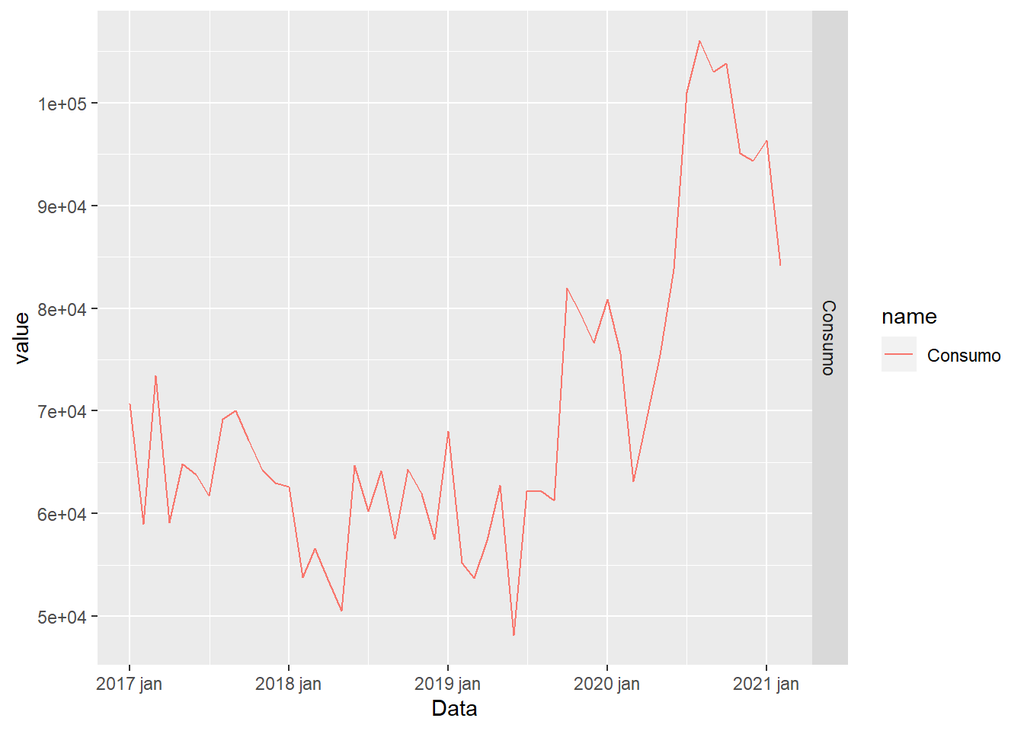

```r
serie %>%
  pivot_longer(-Data) %>%
  ggplot(aes(x = Data, y = value, colour = name)) +
  geom_line() +
  facet_grid(name ~ ., scales = "free_y")
```

## 4.5 Estudo da váriavel consumo

### 4.5.1 ACF e PACF das Séries

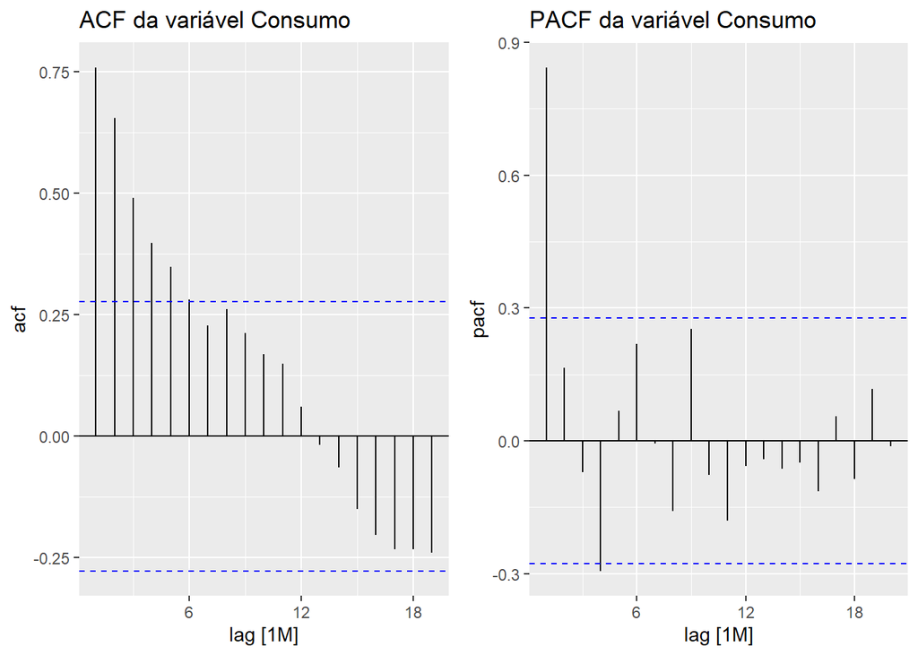

```r
acf_consumo = serie %>%
  ACF(Consumo, lag_max = 20) %>%
  autoplot() + labs(title="ACF da variável Consumo")

pacf_consumo = serie %>%
  PACF(Consumo, lag_max = 20)%>%
  autoplot() + labs(title="PACF da variável Consumo")

gridExtra::grid.arrange(acf_consumo, pacf_consumo, ncol=2)
```

## 4.6 Estudando a sazonalidade

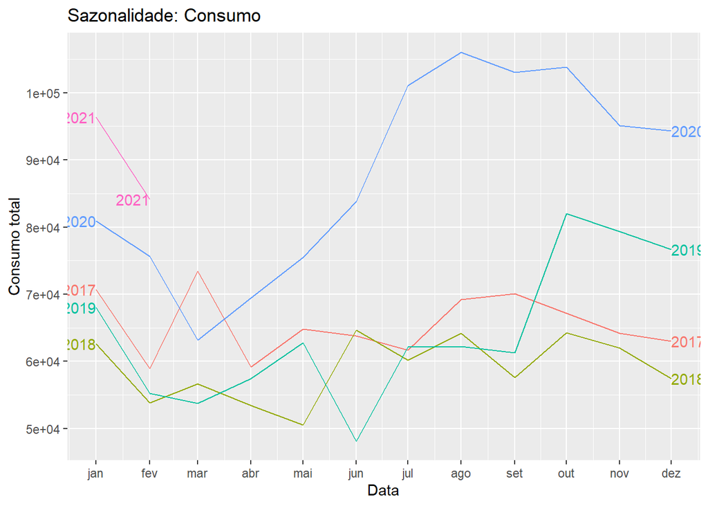

```r
serie %>%
  gg_season(Consumo, labels = "both") +
  labs(y = "Consumo total",
       title = "Sazonalidade: Consumo")
```

## 4.7 Subgráficos

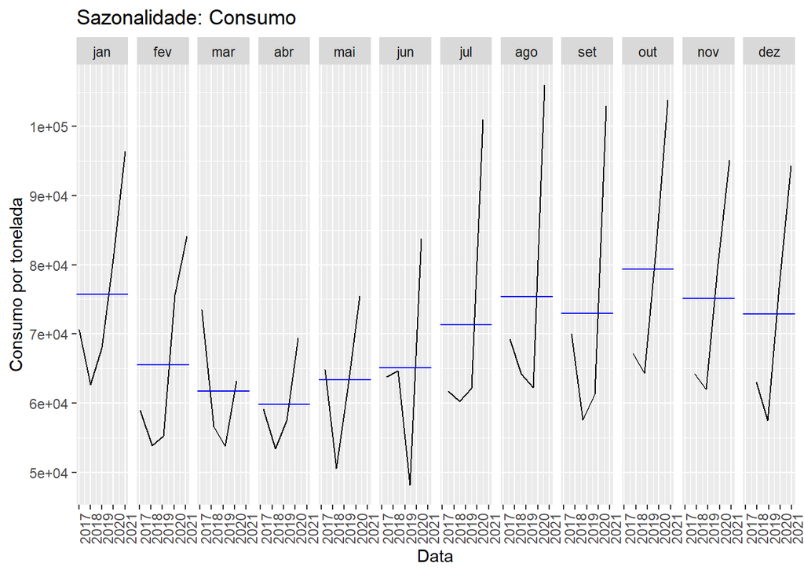

```r
serie %>%
  gg_subseries(Consumo) +
  labs(
    y = "Consumo por tonelada",
    title = "Sazonalidade: Consumo"
  )
```

## 4.8 Extraindo os componentes de uma serie temporal

### 4.8.1 Decomposição aditiva

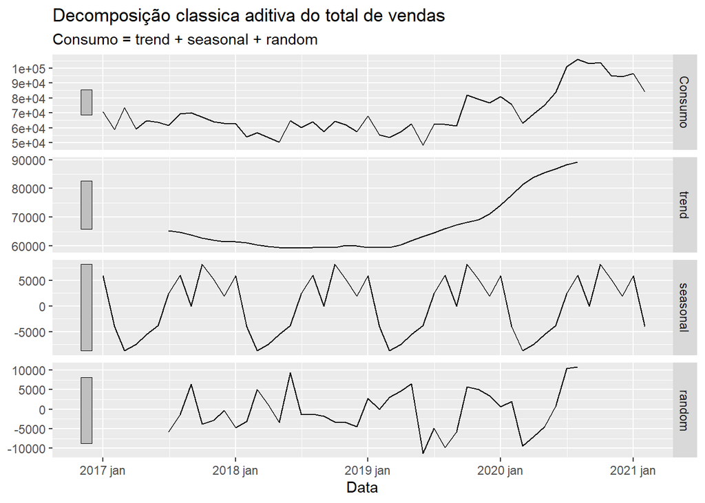

```r
serie %>%
  model(
    classical_decomposition(Consumo, type = "additive")
  ) %>%
  components() %>%
  autoplot() +
  labs(title = "Decomposição classica aditiva do total de vendas")
```

### 4.8.2 Decomposião multiplicativa

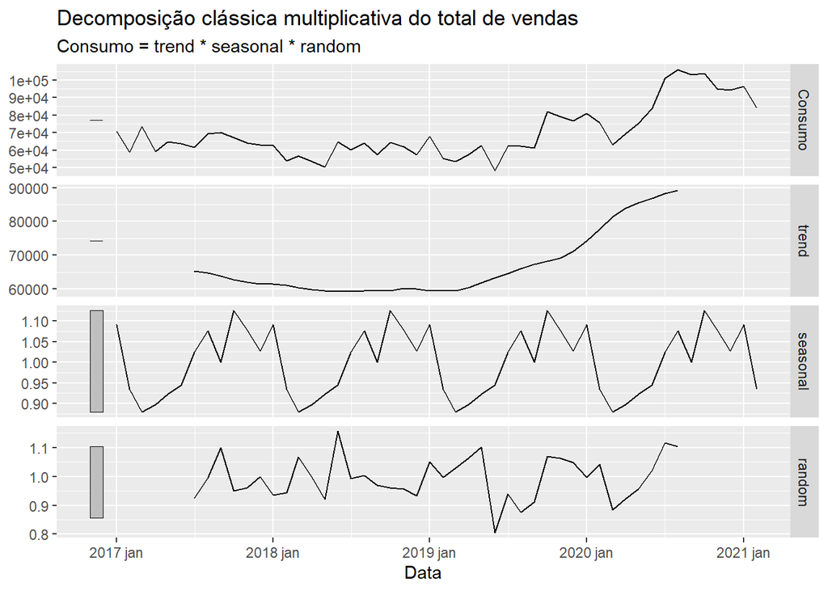

```r
serie %>%
  model(
    classical_decomposition(Consumo, type = "multiplicative")
  ) %>%
  components() %>%
  autoplot() +
  labs(title = "Decomposição clássica multiplicativa do total de vendas")
```

## 4.9 Fazendo a previsão:

### 4.9.1 Para identificar os anos iniciais e finais

```r
head(serie)
```

```
## # A tsibble: 6 x 2 [1M]
##       Data Consumo
##      <mth>   <dbl>
## 1 2017 jan   70672
## 2 2017 fev   58962
## 3 2017 mar   73459
## 4 2017 abr   59150
## 5 2017 mai   64833
## 6 2017 jun   63840
```

```r
tail(serie)
```

```
## # A tsibble: 6 x 2 [1M]
##       Data Consumo
##      <mth>   <dbl>
## 1 2020 set  103000
## 2 2020 out  103842
## 3 2020 nov   95093
## 4 2020 dez   94341
## 5 2021 jan   96375
## 6 2021 fev   84138
```

### 4.9.2 Definindo a base de dados em treinamento e teste

```r
train <- serie %>%
  filter_index("2017" ~ "2021")
test <- serie %>%
  filter_index("2021" ~ .);test
```

```
## # A tsibble: 2 x 2 [1M]
##       Data Consumo
##      <mth>   <dbl>
## 1 2021 jan   96375
## 2 2021 fev   84138
```

### 4.9.3 Verificando se está correto

```r
head(train)
```

```
## # A tsibble: 6 x 2 [1M]
##       Data Consumo
##      <mth>   <dbl>
## 1 2017 jan   70672
## 2 2017 fev   58962
## 3 2017 mar   73459
## 4 2017 abr   59150
## 5 2017 mai   64833
## 6 2017 jun   63840
```

```r
tail(train)
```

[output not shown]

### 4.9.4 Estimando o modelo de suavizacao

```r
consumo_fit <- train %>%
  model(
    ETS = ETS(Consumo)
  )
consumo_fit
```

```
## # A mable: 1 x 1
##            ETS
##        <model>
## 1 <ETS(A,N,N)>
```

```r
consumo_fc <- consumo_fit %>% forecast(h = 20)
consumo_fc
```

```
## # A fable: 20 x 4 [1M]
## # Key:     .model [1]
##    .model     Data           Consumo  .mean
##    <chr>     <mth>            <dist>  <dbl>
##  1 ETS    2021 fev N(96051, 5.9e+07) 96051.
##  2 ETS    2021 mar   N(96051, 9e+07) 96051.
##  3 ETS    2021 abr N(96051, 1.2e+08) 96051.
##  4 ETS    2021 mai N(96051, 1.5e+08) 96051.
##  5 ETS    2021 jun N(96051, 1.8e+08) 96051.
##  6 ETS    2021 jul N(96051, 2.1e+08) 96051.
##  7 ETS    2021 ago N(96051, 2.5e+08) 96051.
##  8 ETS    2021 set N(96051, 2.8e+08) 96051.
##  9 ETS    2021 out N(96051, 3.1e+08) 96051.
## 10 ETS    2021 nov N(96051, 3.4e+08) 96051.
## 11 ETS    2021 dez N(96051, 3.7e+08) 96051.
## 12 ETS    2022 jan   N(96051, 4e+08) 96051.
## 13 ETS    2022 fev N(96051, 4.3e+08) 96051.
## 14 ETS    2022 mar N(96051, 4.6e+08) 96051.
## 15 ETS    2022 abr N(96051, 4.9e+08) 96051.
## 16 ETS    2022 mai N(96051, 5.2e+08) 96051.
## 17 ETS    2022 jun N(96051, 5.6e+08) 96051.
## 18 ETS    2022 jul N(96051, 5.9e+08) 96051.
## 19 ETS    2022 ago N(96051, 6.2e+08) 96051.
## 20 ETS    2022 set N(96051, 6.5e+08) 96051.
```